# Spanish TDT movies report

Guillermo Diaz

2022-10-27

# Introduction

[GitHub](https://github.com/GuilleDiaz7)

This line of code is quite magical. Change any `opts_chunk` here and it will change setting for the entire document. You can set any option you want: `echo`, `include`, `warning` or `messages`.

```r
knitr::opts_chunk$set(
    echo = TRUE,
    message = FALSE,
    warning = FALSE
)
```

# Load and clean data

```r
df <- data %>% mutate(
  genre = replace(genre, genre == "Suspense / Thriller", "Suspense"),
  genre = replace(genre, genre == "Documentales", "Documental"),
  genre = replace(genre, genre == "Ciencia ficci?n", "SyFy"),
  genre = replace(genre, genre == "Infantil/Familiar", "Infantil")
)
```

The data set contains 1450 instances and 16 variables. From now on, we won’t be using the variable `Description` and a bunch more related to the creators of the film (directors, writers, actors, etc).

Let’s see a few examples of the data

```r
# Hay varios temas predeterminados en kableExtra, como kable_paper()
df_clean %>%
  head(6) %>%
  knitr::kable() %>%
  kable_styling(bootstrap_options = c("striped", "hover", "condensed"), full_width = T)
```

| Date | Channel | Spanish title | Original title | Year | Genre | Country | Length |
| --- | --- | --- | --- | --- | --- | --- | --- |
| 2022-09-13 00:19:00 | Paramount Network | Vanilla Sky | Vanilla Sky | 2001 | Drama | Estados Unidos | 130 |
| 2022-09-13 00:42:00 | Neox | Ruslan: la venganza del asesino | Driven to Kill | 2009 | Acción | Canadá | 98 |
| 2022-09-13 01:10:00 | laSexta | La mujer del pastor | The Pastor’s Wife | 2011 | Drama | Canadá | 87 |
| 2022-09-13 13:10:00 | La 2 | El sonido de un tambor | Cimarron: The Sound of a Drum | 1968 | Western | Estados Unidos | 70 |
| 2022-09-13 16:05:00 | TRECE | Comando secreto | The Secret War of Harry Frigg | 1968 | Comedia | Estados Unidos | 110 |
| 2022-09-13 16:20:00 | La 1 | La cuchara de Elli | Tessa Hennig - Elli gibt den Löffel ab | 2012 | Drama | Alemania | 90 |

# Some basic facts about the dataset

## How many films have been shown in each channel?

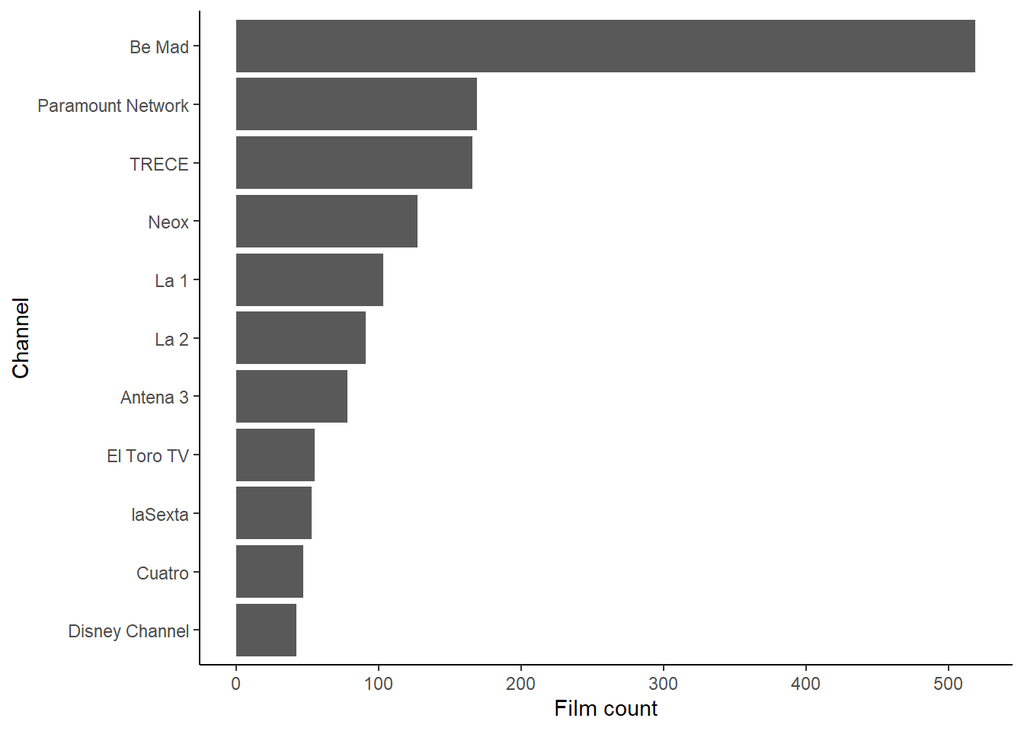

```r
library(ggplot2)

df_clean %>%
  group_by(Channel) %>%
  summarise(`Film count` = n()) %>%
  ggplot(aes(x = `Film count`, y = reorder(Channel, `Film count`))) +
  geom_bar(stat = 'identity') +
  theme_classic() +
  ylab("Channel")
```

## How many unique values there are in each variable?

```r
library(purrr)
df_clean %>% map_dbl(
  n_distinct) %>%
  knitr::kable() %>%
  kable_styling(bootstrap_options = c("striped", "hover", "condensed"), full_width = T)
```

|  | x |
| --- | --- |
| Date | 1319 |
| Channel | 11 |
| Spanish title | 971 |
| Original title | 963 |
| Year | 83 |
| Genre | 22 |
| Country | 30 |
| Length | 119 |

So, if there are 1450 instances, why do we only have 971 movies? I guess some of them were broadcasted more than once. This is the top 10 (I filtered a couple of instances that are not films, but regular TV programs):

```r
df_clean %>%
  filter(`Spanish title` != "Mejor llama a Kiko" & `Spanish title` != "El zapping de Surferos") %>%
  group_by(`Spanish title`) %>%
  summarise(Emisiones = n()) %>%
  filter(Emisiones > 1) %>%
  arrange(desc(Emisiones)) %>%
  head(10) %>%
  knitr::kable() %>%
  kable_styling(bootstrap_options = c("striped", "hover", "condensed"), full_width = T)
```

| Spanish title | Emisiones |
| --- | --- |
| Querido fotogramas | 15 |
| Spanish Movie | 7 |
| Diario de Greg 2: La Ley de Rodrick | 5 |
| El diario de Greg | 5 |
| Locos por las motos | 5 |
| Zombies 3 | 5 |
| Cuenta conmigo | 4 |
| Dreamer: Camino hacia la victoria | 4 |
| El agente | 4 |
| Enemigos. Ecks contra Sever | 4 |

```r
df_clean %>%
  group_by(`Original title`) %>%
  distinct() %>%
  filter(n()>1) %>%
  arrange(`Original title`) %>%
  select(3:4) %>%
  distinct(`Spanish title`) %>%
  mutate(Count = n()) %>%
  filter(Count >= 2) %>%
  select(-Count) %>%
  knitr::kable() %>%
  kable_styling(bootstrap_options = c("striped", "hover", "condensed"), full_width = T)
```

| Spanish title | Original title |
| --- | --- |
| Asteroides, el nuevo dorado | Astéroïdes, le nouvel eldorado spatial? |
| Asteroides, el nuevo El Dorado | Astéroïdes, le nouvel eldorado spatial? |
| El cabo del miedo | Cape Fear |
| El Cabo del Terror | Cape Fear |
| El justiciero de la ciudad | Death Wish |
| El justiciero | Death Wish |
| Dragon: la vida de Bruce Lee | Dragon: The Bruce Lee Story |
| Dragón: la vida de Bruce Lee | Dragon: The Bruce Lee Story |
| Aventura en el centro de la Tierra | Journey to the Center of the Earth |
| Viaje al centro de la tierra | Journey to the Center of the Earth |
| Robin Hood, el magnífico | Robin Hood |
| Robin Hood | Robin Hood |
| El Padrino II | The Godfather: Part II |
| El Padrino parte II | The Godfather: Part II |
| El último patriota | The Patriot |
| El patriota | The Patriot |
| El estrafalario prisionero de Zenda | The Prisoner of Zenda |
| El prisionero de Zenda | The Prisoner of Zenda |
| The Score (Un golpe maestro) | The Score |
| Un golpe maestro | The Score |

# Film length

## How long are the films shown in TV?

This is the distribution of film length. The mean is 99 and the median 99.

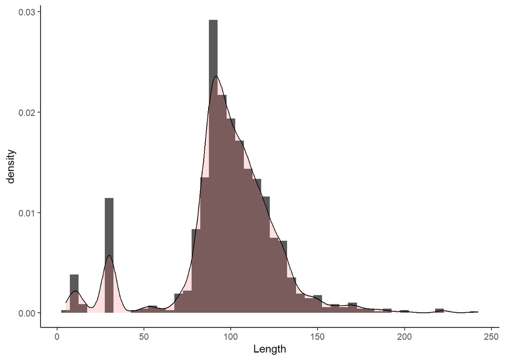

```r
library(ggplot2)
df_clean %>%
  drop_na() %>%
  ggplot(aes(x = Length)) +
    geom_histogram(aes(y=..density..), binwidth = 5) +
    geom_density(alpha = 0.2, fill = "#FF6666") +
    theme_classic()
```

Let’s see how it is by channel.

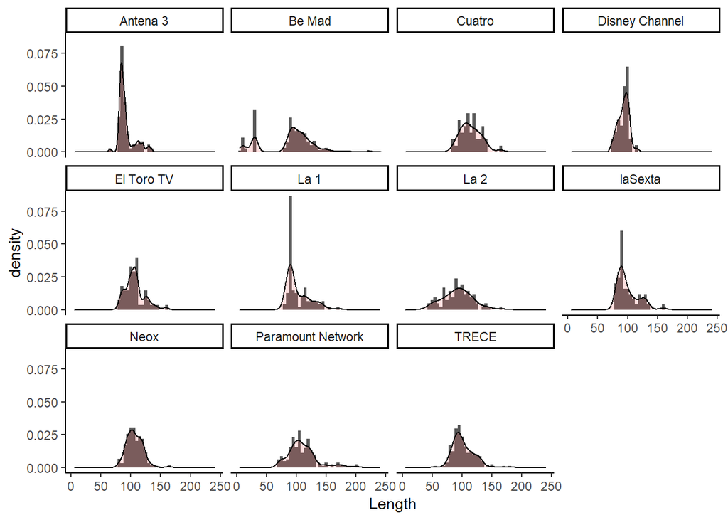

```r
df_clean %>%
  drop_na() %>%
  ggplot(aes(x = Length)) +
    geom_histogram(aes(y=..density..), binwidth = 5) +
    geom_density(alpha = 0.2, fill = "#FF6666") +
    facet_wrap(~ Channel) +
    theme_classic()
```

A violin plot (a boxplot would be useful too) may be easier to interpret. It is remarkable how similar are lengths in Antena 3 channel.

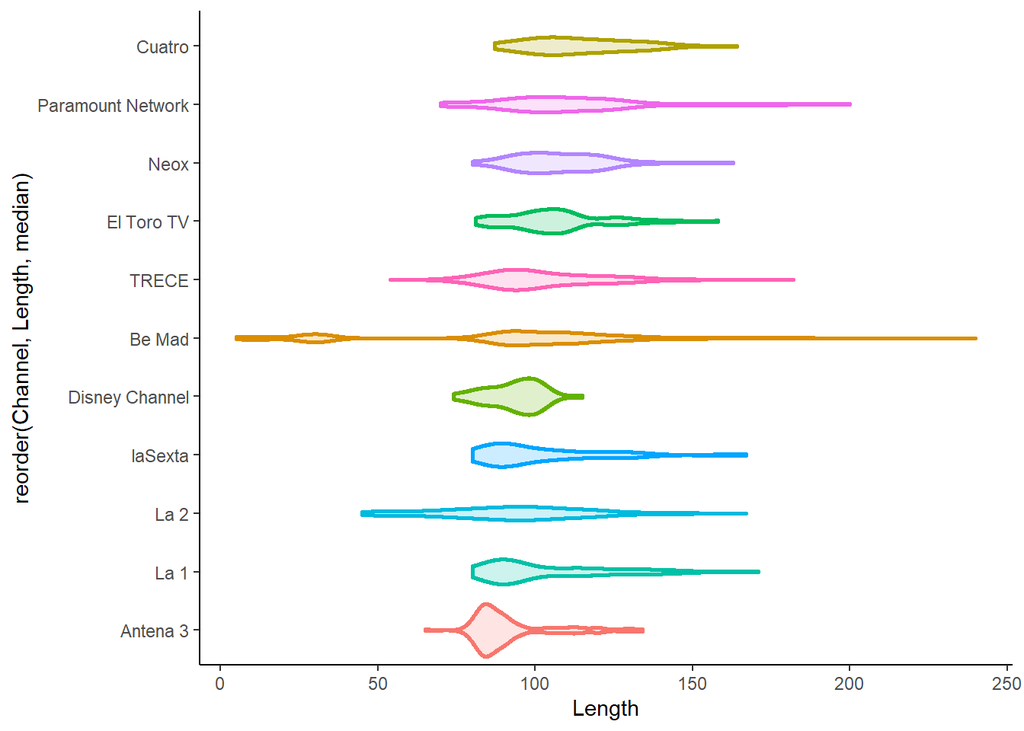

```r
df_clean %>%
  ggplot(aes(x = Length, y = reorder(Channel, Length, median),
             color = Channel, fill = Channel)) +
  geom_violin(size = 0.9, alpha = 0.2, show.legend = F) +
  theme_classic()
```

```r
four_shortest <- df_clean %>%
  group_by(Channel) %>%
  summarise(Median = median(Length)) %>%
  arrange(Median) %>%
  slice_head(n = 4) %>%
  select(-Median) %>%
  as.list() %>%
  unname() %>%
  unlist()
```

Why are Antena 3, La 1, La 2 and laSexta broadcasting the shortest films? Let’s have a glimpse.

```r
library(stringr)
library(kableExtra)
library(lubridate)

df_clean %>%
  mutate("Weekday" = weekdays.Date(Date, abbreviate = F)) %>%
  relocate("Weekday", .after = Date) %>%
  transmute(
    Date = Date,
    Channel = Channel,
    `Spanish title` = `Spanish title`,
    "Weekday" = case_when(
      str_detect(iconv(Weekday, to='ASCII//TRANSLIT'), regex("lunes|martes|miercoles|jueves", ignore_case = T)) ~ "Laboral",
      str_detect(iconv(Weekday, to='ASCII//TRANSLIT'), regex("viernes|sabado|domingo", ignore_case = T)) ~ "Finde"
      ),
    Length = Length
    ) %>%
  filter(Channel == four_shortest) %>%
  arrange(Length) %>%
  head(15) %>%
  knitr::kable() %>%
  kable_styling(bootstrap_options = c("striped", "hover", "condensed"), full_width = T)
```

| Date | Channel | Spanish title | Weekday | Length |
| --- | --- | --- | --- | --- |
| 2022-10-06 23:55:00 | La 2 | Andrea Camilleri: El maestro sin reglas | Laboral | 52 |
| 2022-10-02 01:02:00 | La 2 | Asteroides, el nuevo dorado | Finde | 53 |
| 2022-10-22 21:00:00 | La 2 | La odisea de las especias | Finde | 60 |
| 2022-10-04 13:10:00 | La 2 | Sin honor | Laboral | 70 |
| 2022-10-06 13:10:00 | La 2 | Los testigos | Laboral | 70 |
| 2022-09-20 13:20:00 | La 2 | Hasta el final de la noche | Laboral | 71 |
| 2022-10-12 13:25:00 | La 2 | Whitey | Laboral | 71 |
| 2022-10-15 17:45:00 | Antena 3 | Obsesión del pasado | Finde | 79 |
| 2022-09-29 00:40:00 | La 2 | Una esvástica sobre el Bidasoa | Laboral | 80 |
| 2022-10-18 01:10:00 | laSexta | Testigo presencial | Laboral | 80 |
| 2022-10-20 13:00:00 | La 2 | El jinete solitario | Laboral | 80 |
| 2022-09-23 00:43:00 | laSexta | Edad de hielo | Finde | 81 |
| 2022-10-12 19:30:00 | Antena 3 | Viviendo con una extraña | Laboral | 81 |
| 2022-10-21 00:34:00 | laSexta | Un extraño en mi casa | Finde | 82 |
| 2022-10-23 16:00:00 | Antena 3 | La acusación de Rachel | Finde | 82 |

Now we transform `Length` in three categories being (1) less than 90 minutes, (2) between 90 and 150 minutes and (3) more than 150 minutes.

```r
df_clean <- df_clean %>%
  mutate(
    length_category = case_when(
      Length <= 90 ~ "Less than 90 minutes",
      Length > 90 & Length <= 150 ~ "Between 90 and 150 minutes",
      Length > 150 ~ "More than 150 minutes",
      TRUE ~ "Rest"
    )
  )
```

#### Not color-blind graphic

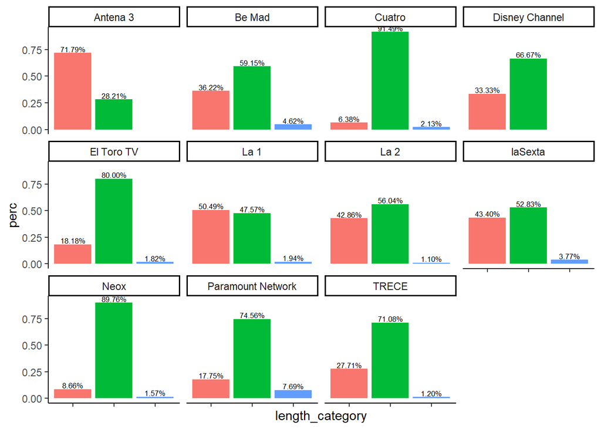

```r
perc_data <- df_clean %>%
    mutate(length_category = factor(length_category, levels = c("Less than 90 minutes",
                                                      "Between 90 and 150 minutes", "More than 150 minutes"))) %>%
  group_by(Channel) %>%
  mutate(Channel_shown = n()) %>%
  group_by(Channel, length_category) %>%
  summarise(perc = n()/max(Channel_shown))

library(scales) # For percent

perc_data %>%
  ggplot(aes(x = length_category, y = perc, fill = length_category)) +
  geom_bar(stat = 'identity', show.legend = "none") +
  facet_wrap(~ Channel) +
  geom_text(aes(label = percent(perc)), vjust = -0.2, size = 2.3) +
  theme_classic() +
  theme(axis.text.x = element_blank())
```

#### Color-blind graphic

```r
library(ggtext)
library(thematic)
# Color-blind safe colors
coloritos <- thematic::okabe_ito(3)
```

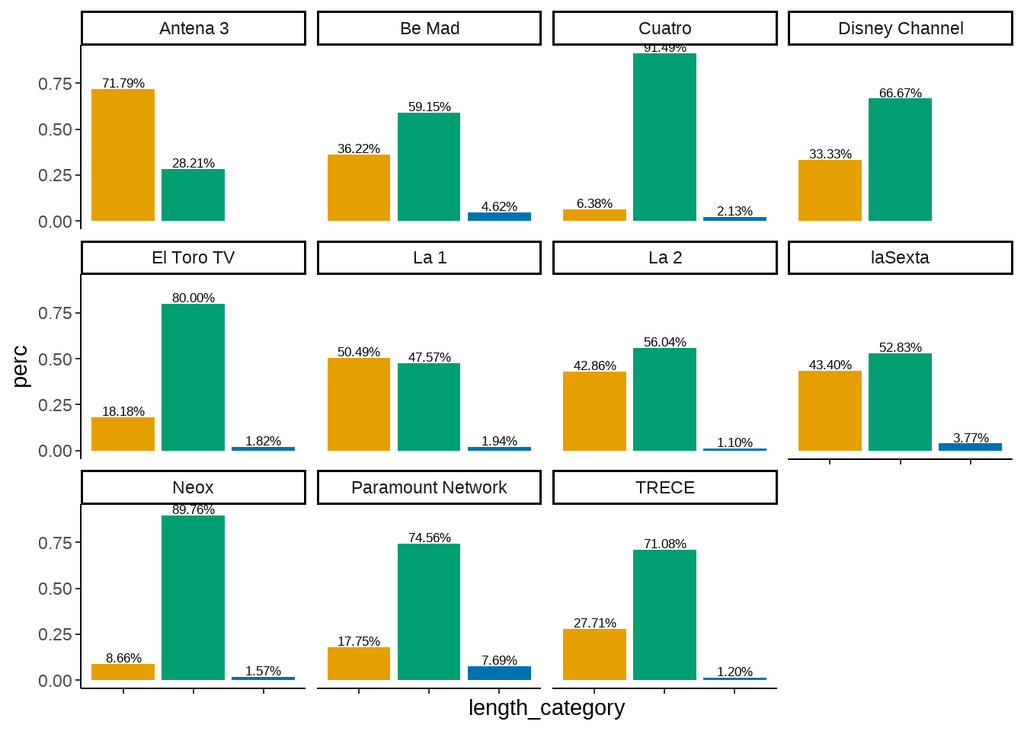

```r
perc_data %>%
  ggplot(aes(x = length_category, y = perc, fill = length_category)) +
  geom_bar(stat = 'identity', show.legend = "none") +
  scale_fill_manual(values = coloritos) +
  facet_wrap(~ Channel) +
  geom_text(aes(label = percent(perc)), vjust = -0.2, size = 2.3) +
  theme_classic() +
  theme(axis.text.x = element_blank())
```

# By date

This is a list of the number of films shown each day.

```r
library(stringr)
library(kableExtra)
library(lubridate)

df_clean_film_day <- df_clean %>%
  mutate("Weekday" = weekdays.Date(Date, abbreviate = F)) %>%
  relocate("Weekday", .after = Date) %>%
  transmute(
    Date = Date,
    "Weekday" = case_when(
      str_detect(iconv(Weekday, to='ASCII//TRANSLIT'), regex("lunes|martes|miercoles|jueves", ignore_case = T)) ~ "Laboral",
      str_detect(iconv(Weekday, to='ASCII//TRANSLIT'), regex("viernes|sabado|domingo", ignore_case = T)) ~ "Finde"
      )
    ) %>%
  group_by(
    Date = as.Date(Date), Weekday) %>%
  summarise(Films = n())


df_clean_film_day %>%
  head(10) %>%
  knitr::kable() %>%
  kable_styling(bootstrap_options = c("striped", "hover", "condensed"), full_width = T)
```

| Date | Weekday | Films |
| --- | --- | --- |
| 2022-09-13 | Laboral | 11 |
| 2022-09-14 | Laboral | 13 |
| 2022-09-15 | Laboral | 11 |
| 2022-09-16 | Finde | 20 |
| 2022-09-17 | Finde | 38 |
| 2022-09-18 | Finde | 34 |
| 2022-09-19 | Laboral | 17 |
| 2022-09-20 | Laboral | 22 |
| 2022-09-21 | Laboral | 23 |
| 2022-09-22 | Laboral | 27 |

There is a surprising spike on Wednesday 12th October which is not that surpring when I tell you that it is Spanish national day.

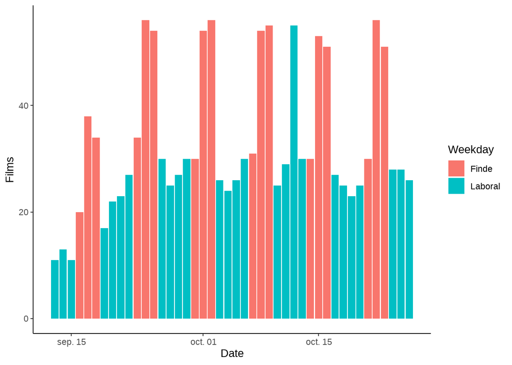

```r
df_clean_film_day %>%
  ggplot(aes(x = Date, y = Films, fill = Weekday)) +
  geom_col() +
  theme_classic()
```

# Mapping the data (or analyzing the country variable)

First, we have to prepare the data. Country names are in Spanish, let’s translate them.

```r
unique(df_clean$Country)
```

```
##  [1] "Estados Unidos"     "Canadá"             "Alemania"
##  [4] "España"             "Italia"             "Francia"
##  [7] "Reino Unido"        "Dinamarca"          "Sudáfrica"
## [10] "Australia"          "Corea del Sur"      "Tailandia"
## [13] "Suecia"             "Rusia"              "China"
## [16] "Hong Kong"          "Islandia"           "Argentina"
## [19] "República Checa"    "Noruega"            "Países Bajos"
## [22] "Bélgica"            "Turquía"            "Taiwán"
## [25] "Alemania del Oeste" "Irlanda"            "Ucrania"
## [28] NA                   "Japón"              "México"
```

I will check for empty values in the `Country` variable. If there isn’t we will continue.

```r
df_clean %>%
  filter(Country == "")
```

```
## # A tibble: 0 x 9
## # ... with 9 variables: Date <dttm>, Channel <chr>, Spanish title <chr>,
## #   Original title <chr>, Year <dbl>, Genre <chr>, Country <chr>, Length <dbl>,
## #   length_category <chr>
```

```r
df_map <- df_clean %>%
  group_by(`Country`) %>%
  summarise(Movies = n())

df_map <- df_map %>%
  mutate(
    Country = case_when(
      Country == "Alemania" ~ "Germany",
      Country == "Alemania del Oeste" ~ "Germany",
      Country == "Argentina" ~ "Argentina",
      Country == "Australia" ~ "Australia",
      Country == "Bélgica" ~ "Belgium",
      Country == "Canadá" ~ "Canada",
      Country == "China" ~ "China",
      Country == "Corea del Sur" ~ "South Korea",
      Country == "Dinamarca" ~ "Denmark",
      Country == "España" ~ "Spain",
      Country == "Estados Unidos" ~ "United States of America",
      Country == "Francia" ~ "France",
      Country == "Hong Kong" ~ "Hong Kong",
      Country == "Irlanda" ~ "Ireland",
      Country == "Islandia" ~ "Island",
      Country == "Italia" ~ "Italy",
      Country == "Noruega" ~ "Norway",
      Country == "Países Bajos" ~ "Netherlands",
      Country == "Reino Unido" ~ "United Kingdom",
      Country == "República Checa" ~ "Czech Republic",
      Country == "Rusia" ~ "Russia",
      Country == "Sudáfrica" ~ "South Africa",
      Country == "Suecia" ~ "Sweden",
      Country == "Tailandia" ~ "Tailand",
      Country == "Taiwán" ~ "Taiwan",
      Country == "Turquía" ~ "Turkey",
      Country == "Ucrania" ~ "Ukraine",
      is.na(Country) == TRUE ~ "Sin datos"
    )
  )

df_map %>%
  arrange(desc(Movies)) %>%
  knitr::kable() %>%
  kable_styling(bootstrap_options = c("striped", "hover", "condensed"), full_width = T)
```

| Country | Movies |
| --- | --- |
| United States of America | 897 |
| Spain | 232 |
| Sin datos | 86 |
| United Kingdom | 55 |
| Germany | 47 |
| Canada | 42 |
| France | 28 |
| Italy | 18 |
| Australia | 9 |
| South Korea | 6 |
| Norway | 5 |
| Argentina | 2 |
| China | 2 |
| Hong Kong | 2 |
| Ireland | 2 |
| Russia | 2 |
| Sweden | 2 |
| Germany | 1 |
| Belgium | 1 |
| Denmark | 1 |
| Island | 1 |
| NA | 1 |
| NA | 1 |
| Netherlands | 1 |
| Czech Republic | 1 |
| South Africa | 1 |
| Tailand | 1 |
| Taiwan | 1 |
| Turkey | 1 |
| Ukraine | 1 |

First, let’s use a bar plot. Mmm, we do seem to like USA films…

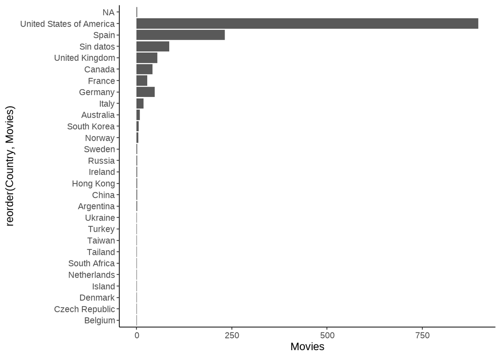

```r
df_map %>%
  ggplot(aes(x = reorder(Country, Movies), y = Movies)) +
  geom_bar(stat = 'identity') +
  coord_flip() +
  theme_classic()
```

Then, we plot a map.

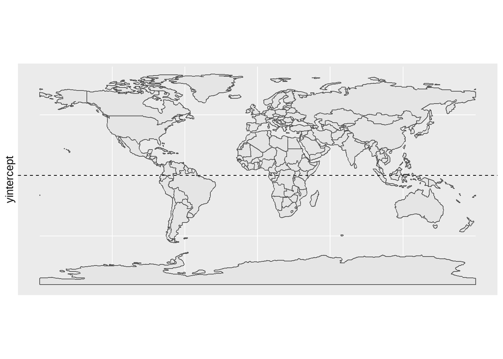

```r
library(sf)
library(rnaturalearth)

world <- ne_countries(scale = "small", returnclass = "sf")

world %>%
  ggplot() +
  geom_sf() +
  geom_hline(yintercept = 0, linetype = "dashed")
```

```r
world <- world %>%
  dplyr::rename("Country" = "sovereignt")

df_world <- left_join(world, df_map)
```

Let’s see how it looks filled.

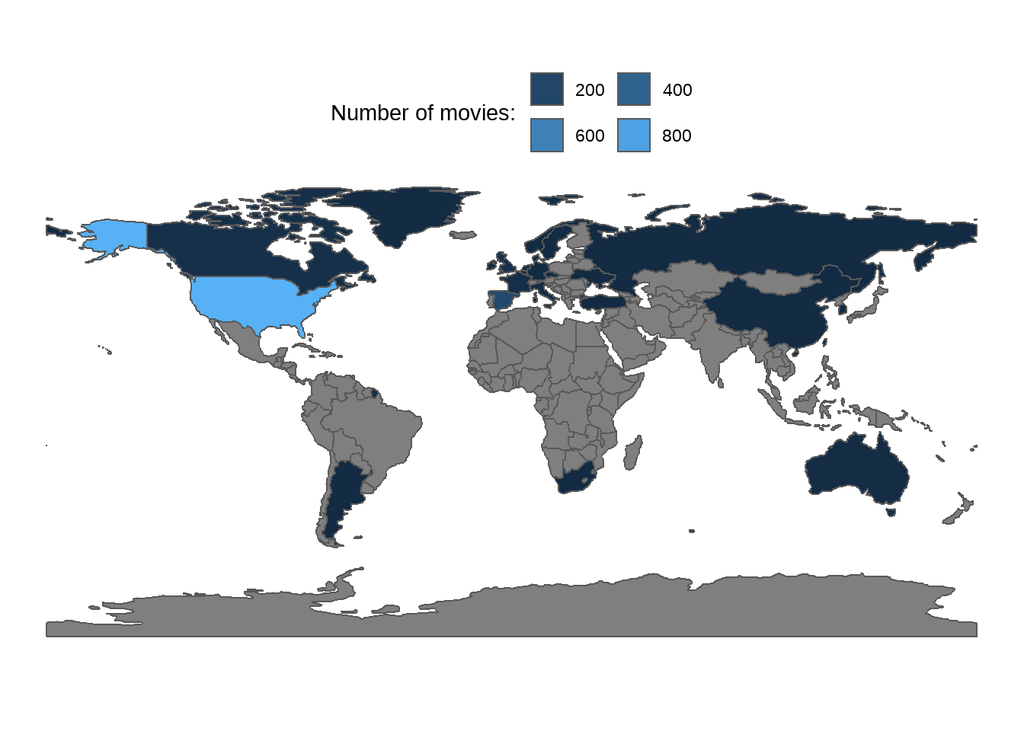

```r
library(ggplot2)
library(sf)
df_world %>%
  ggplot() +
  geom_sf(aes(fill = Movies)) +
  theme_void() +
  theme(legend.position = "top") +
  labs(fill = "Number of movies:") +
  guides(fill = guide_legend(nrow = 2, byrow = TRUE))
```

I will plot the same map but without United States (and maybe without Spain too). The scale is very confusing as it is.

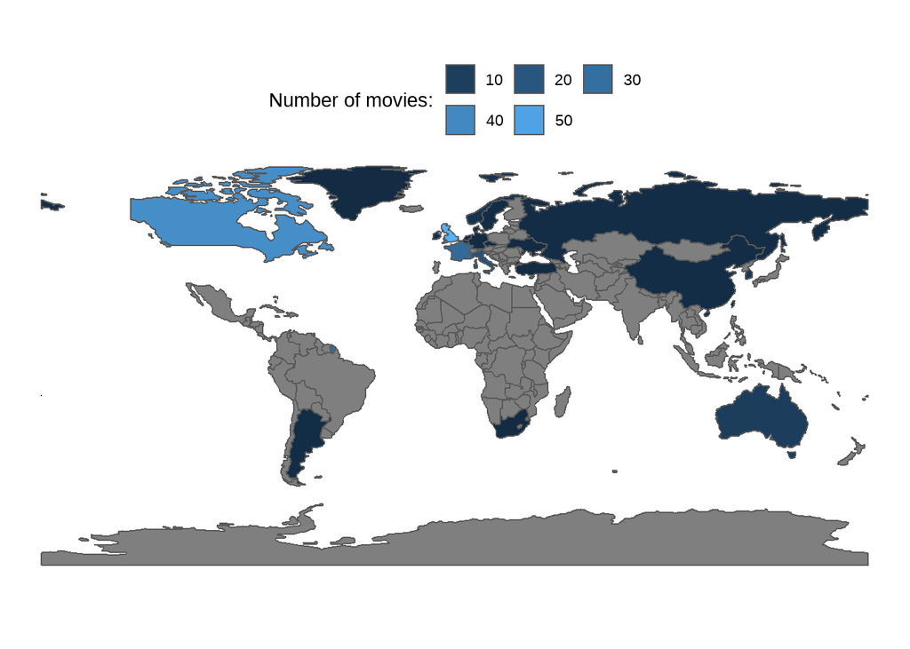

```r
df_world %>%
  filter(Country != "United States of America" & Country != "Spain") %>%
  ggplot() +
  geom_sf(aes(fill = Movies)) +
  theme_void() +
  theme(legend.position = "top") +
  labs(fill = "Number of movies:") +
  guides(fill = guide_legend(nrow = 2, byrow = TRUE))
```

I want to see the Country distribution by channel; for example, to analize which channel promote Spanish cinema. Or how the public channels behave.

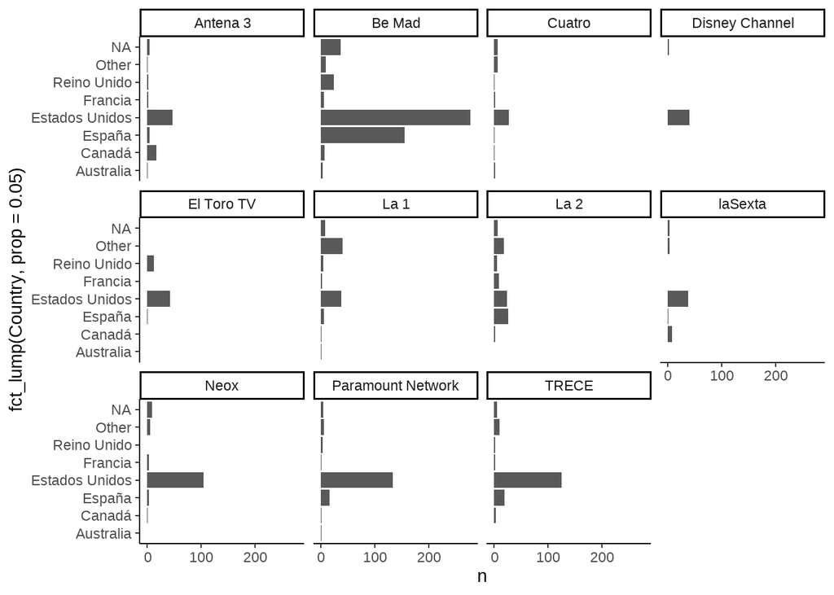

```r
library(forcats)
df_clean %>%
  group_by(Channel, Country) %>%
  count(Country) %>%
  ggplot(aes(x = fct_lump(Country, prop = 0.05), y = n)) +
  geom_col() +
  facet_wrap(~Channel) +
  coord_flip() +
  theme_classic()
```

This we we can see better how Countries are distributed within each channel.

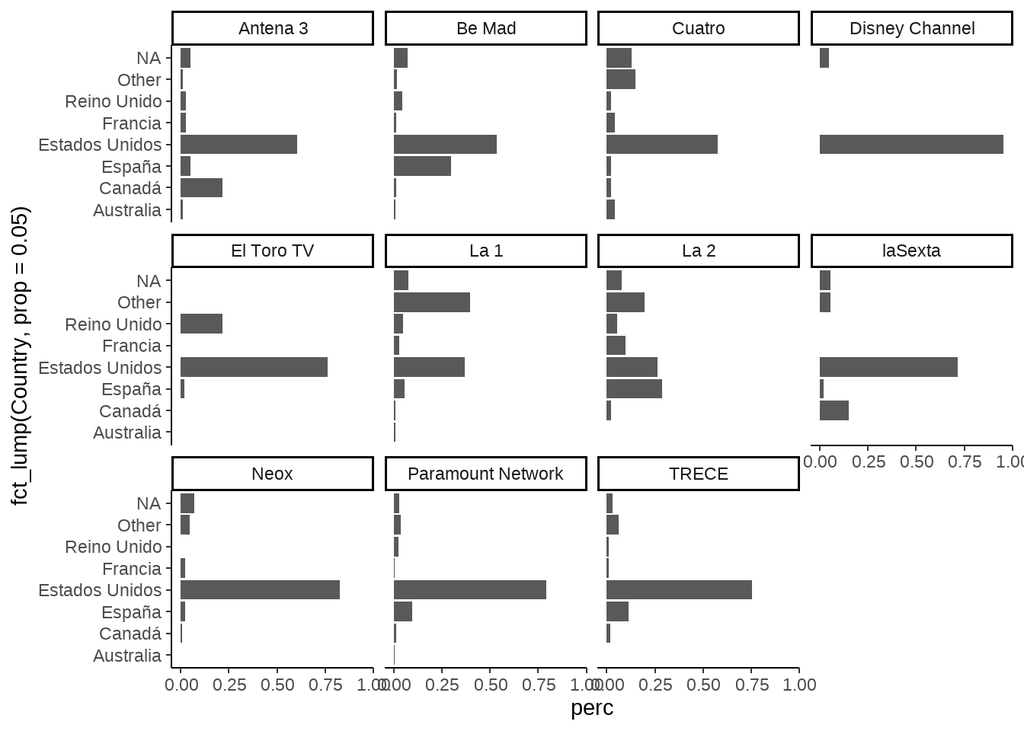

```r
perc_data_2 <- df_clean %>%
  group_by(Channel) %>%
  mutate(Channel_shown = n()) %>%
  group_by(Channel, Country, Channel_shown) %>%
  summarise(perc = n()/max(Channel_shown))

perc_data_2 %>%
  ggplot(aes(x = fct_lump(Country, prop = 0.05), y = perc)) +
  geom_col() +
  facet_wrap(~Channel) +
  coord_flip() +
  theme_classic()
```

I want to do the same but removing films from United States.

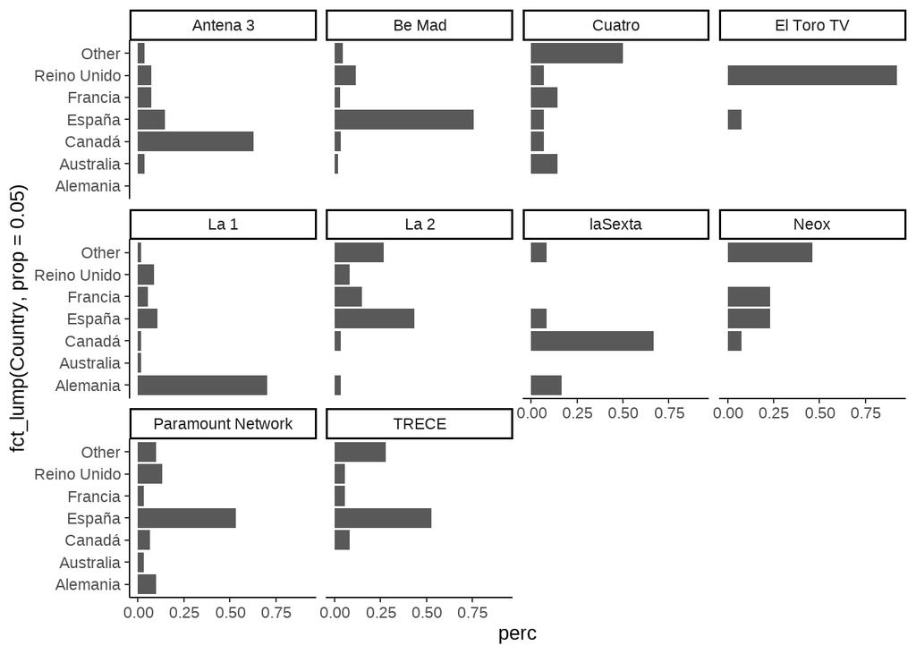

```r
perc_data_3 <- df_clean %>%
  filter(Country != "Estados Unidos") %>%
  group_by(Channel) %>%
  mutate(Channel_shown = n()) %>%
  group_by(Channel, Country, Channel_shown) %>%
  summarise(perc = n()/max(Channel_shown))


perc_data_3 %>%
  ggplot(aes(x = fct_lump(Country, prop = 0.05), y = perc)) +
  geom_col() +
  facet_wrap(~Channel) +
  coord_flip() +
  theme_classic()
```